# Classification - KNN

2019-08-15

Breast Cancer problem.

# Setting up Rmarkdown

# Loading Librais

```r
library(tidyverse)
library(tidymodels)
library(janitor)
library(skimr)
library(DataExplorer)
```

Loading Libraries: 4.87 sec elapsed

Loading Libraries: 4.78 sec elapsed

# Getting Data

Got the dataset with headers on [kaggle link](https://www.kaggle.com/uciml/breast-cancer-wisconsin-data/version/2)

```r
df <- read_csv("breast_cancer.csv")
```

Set Chunk: 0.24 sec elapsed

There is a strange extra column named X33 dealing with that using janitor package

```r
df <- df %>%
  janitor::remove_empty_cols()
```

Cleaning Data: 0.02 sec elapsed

# Visualizing the data using DataExplorer and Skimr

## Skimr is a fast way to get info on your data even though the hist plot fails on my blog :(

```r
df %>%
  skimr::skim() %>%
  skimr::kable()
```

```
## Skim summary statistics
##  n obs: 569
##  n variables: 32
##
## Variable type: character
##
##  variable     missing    complete     n     min    max    empty    n_unique
## -----------  ---------  ----------  -----  -----  -----  -------  ----------
##  diagnosis       0         569       569     1      1       0         2
##
## Variable type: numeric
##
##         variable            missing    complete     n      mean       sd         p0        p25       p50        p75       p100        hist
## -------------------------  ---------  ----------  -----  --------  ---------  ---------  --------  --------  ---------  ---------  ----------
##         area_mean              0         569       569    654.89    351.91      143.5     420.3     551.1      782.7      2501      ▅▇▂▂▁▁▁▁
##          area_se               0         569       569    40.34      45.49       6.8      17.85     24.53      45.19      542.2     ▇▁▁▁▁▁▁▁
##        area_worst              0         569       569    880.58    569.36      185.2     515.3     686.5      1084       4254      ▇▅▂▁▁▁▁▁
##     compactness_mean           0         569       569     0.1       0.053      0.019     0.065     0.093      0.13       0.35      ▅▇▆▃▁▁▁▁
##      compactness_se            0         569       569    0.025      0.018     0.0023     0.013      0.02      0.032      0.14      ▇▆▂▁▁▁▁▁
##     compactness_worst          0         569       569     0.25      0.16       0.027      0.15      0.21      0.34       1.06      ▆▇▅▂▁▁▁▁
##    concave points_mean         0         569       569    0.049      0.039        0        0.02     0.034      0.074       0.2      ▇▆▃▃▁▁▁▁
##     concave points_se          0         569       569    0.012     0.0062        0       0.0076    0.011      0.015      0.053     ▃▇▅▁▁▁▁▁
##   concave points_worst         0         569       569     0.11      0.066        0       0.065      0.1       0.16       0.29      ▃▇▇▅▅▃▂▁
##      concavity_mean            0         569       569    0.089      0.08         0        0.03     0.062      0.13       0.43      ▇▃▂▂▁▁▁▁
##       concavity_se             0         569       569    0.032      0.03         0       0.015     0.026      0.042       0.4      ▇▂▁▁▁▁▁▁
##      concavity_worst           0         569       569     0.27      0.21         0        0.11      0.23      0.38       1.25      ▇▆▅▂▁▁▁▁
##  fractal_dimension_mean        0         569       569    0.063     0.0071      0.05      0.058     0.062      0.066      0.097     ▃▇▆▂▁▁▁▁
##   fractal_dimension_se         0         569       569    0.0038    0.0026     0.00089    0.0022    0.0032    0.0046      0.03      ▇▂▁▁▁▁▁▁
##  fractal_dimension_worst       0         569       569    0.084      0.018      0.055     0.071      0.08      0.092      0.21      ▆▇▃▁▁▁▁▁
##            id                  0         569       569    3e+07     1.3e+08     8670      869218    906024    8813129    9.1e+08    ▇▁▁▁▁▁▁▁
##      perimeter_mean            0         569       569    91.97      24.3       43.79     75.17     86.24      104.1      188.5     ▂▇▇▃▂▁▁▁
##       perimeter_se             0         569       569     2.87      2.02       0.76       1.61      2.29      3.36       21.98     ▇▂▁▁▁▁▁▁
##      perimeter_worst           0         569       569    107.26     33.6       50.41     84.11     97.66      125.4      251.2     ▂▇▃▂▂▁▁▁
##        radius_mean             0         569       569    14.13      3.52       6.98       11.7     13.37      15.78      28.11     ▁▆▇▃▂▁▁▁
##         radius_se              0         569       569     0.41      0.28       0.11       0.23      0.32      0.48       2.87      ▇▂▁▁▁▁▁▁
##       radius_worst             0         569       569    16.27      4.83       7.93      13.01     14.97      18.79      36.04     ▂▇▅▂▂▁▁▁
##      smoothness_mean           0         569       569    0.096      0.014      0.053     0.086     0.096      0.11       0.16      ▁▂▇▇▃▁▁▁
##       smoothness_se            0         569       569    0.007      0.003     0.0017     0.0052    0.0064    0.0081      0.031     ▅▇▂▁▁▁▁▁
##     smoothness_worst           0         569       569     0.13      0.023      0.071      0.12      0.13      0.15       0.22      ▁▃▆▇▃▁▁▁
##       symmetry_mean            0         569       569     0.18      0.027      0.11       0.16      0.18       0.2        0.3      ▁▃▇▇▂▁▁▁
##        symmetry_se             0         569       569    0.021     0.0083     0.0079     0.015     0.019      0.023      0.079     ▇▇▃▁▁▁▁▁
##      symmetry_worst            0         569       569     0.29      0.062      0.16       0.25      0.28      0.32       0.66      ▁▇▆▂▁▁▁▁
##       texture_mean             0         569       569    19.29       4.3       9.71      16.17     18.84      21.8       39.28     ▂▆▇▅▂▁▁▁
##        texture_se              0         569       569     1.22      0.55       0.36       0.83      1.11      1.47       4.88      ▆▇▃▁▁▁▁▁
##       texture_worst            0         569       569    25.68      6.15       12.02     21.08     25.41      29.72      49.54     ▂▆▇▆▅▁▁▁
```

Skimr: 0.3 sec elapsed

Skimr: 0.29 sec elapsed

## Data Explorer

Is a imho a prettier option with individual cool plots and a super powerfull(but slow) report creation tool when working outside of an Rmarkdownm document

```r
df %>%
  DataExplorer::plot_intro()
```

[figure not shown]

```r
df %>%
  DataExplorer::plot_bar()
```

[figure not shown]

```r
df %>%
  DataExplorer::plot_correlation()
```

[figure not shown]

Data Explorer individual plots: 1.34 sec elapsed

[figure not shown]

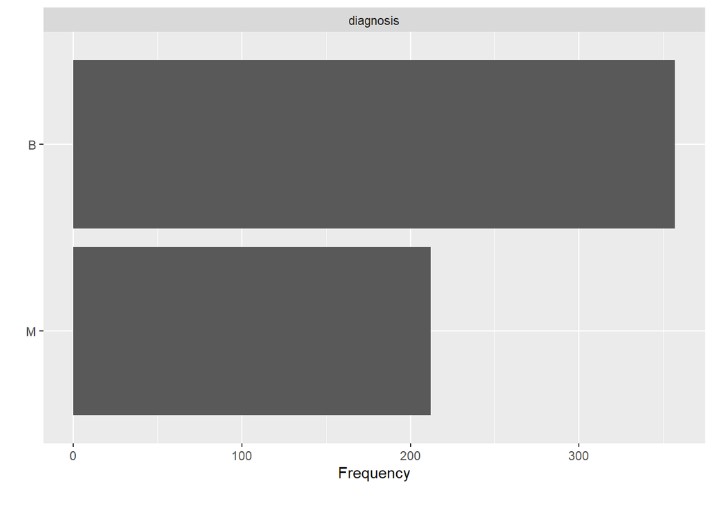

```r
df %>%
  DataExplorer::plot_bar()
```

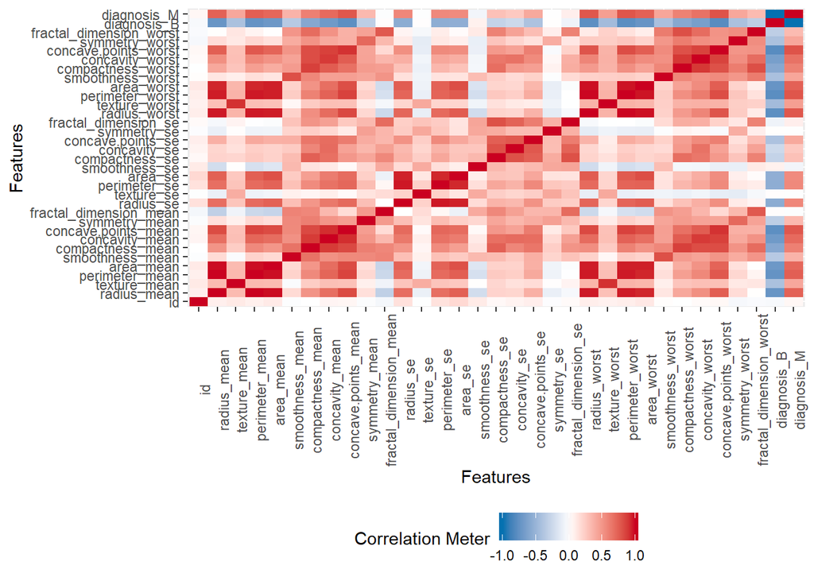

```r
df %>%
  DataExplorer::plot_correlation()
```

Data Explorer individual plots: 1.34 sec elapsed

There are much more amaziong tools such as the [ggforce package](https://www.data-imaginist.com/2019/a-flurry-of-facets/) , but I hope you get the gist of the exploration stage.

# Modeling

For now I am going to focus on the tools provided by the tidymodels packages and the KNN, in the future I may come back to add more models and probably to play around the DALEX package a little bit.

## Train Test Split

Usually we split our data into training and test data to ensure a fair evaluation of the models or parameters being tested(hoping to avoid overfitting).

The workflow for the tidymodels is that we first split our data.

```r
df_split <- df %>%
  rsample::initial_split(prop = 0.8)
df_split
```

```
## <456/113/569>
```

unnamed-chunk-1: 0.02 sec elapsed

Then we model on our Training Data

## Recipes

Recipes are used to preprocess our data, the main mistake here is using the whole data set.

The recipe package helps us with this process.

I am than Normalizing my data since the KNN alghoritm is sensible to the scale of the variables being used, I am also excluding variables with high absolute correlation amongst themselves.

```r
df_recipe <- training(df_split) %>%
  recipe(diagnosis ~ .-id) %>%
  step_center(all_predictors()) %>%
  step_scale(all_predictors(),all_numeric()) %>%
  step_corr(all_predictors()) %>%
  prep()
df_recipe
```

```
## Data Recipe
##
## Inputs:
##
##       role #variables
##    outcome          1
##  predictor         31
##
## Training data contained 456 data points and no missing data.
##
## Operations:
##
## Centering for id, radius_mean, ... [trained]
## Scaling for id, radius_mean, ... [trained]
## Correlation filter removed perimeter_mean, ... [trained]
```

unnamed-chunk-2: 0.08 sec elapsed

We can then create our train and test data frames by baking our recipe and juicing our recipe

```r
df_testing <- df_recipe %>%
  bake(testing(df_split))
df_testing
```

[output not shown]

unnamed-chunk-3: 0.08 sec elapsed

```r
df_training <- juice(df_recipe)
```

unnamed-chunk-4: 0.01 sec elapsed

unnamed-chunk-4: 0 sec elapsed

## Cross Validation and Random Serch

### Cross Validation

We further divide our data frame into folds in order to improve our certainty that the ideal number of neighbours is right.

```r
df_cross_testing <- df_testing %>% vfold_cv(v = 10)
```

unnamed-chunk-5: 0.01 sec elapsed

To decide the KNN parameters we could use the Dials package, grid searchign neighbors 1 to 50, Working on this

```r
bst_grid <- grid_random(
  neighbors %>%  range_set(c( 1,  50)),
  size = 10
)
```

unnamed-chunk-6: 0.01 sec elapsed

```r
nearest_neighbor_model <- parsnip::nearest_neighbor(mode = "classification") %>%
  set_engine("kknn") %>%
  merge(bst_grid)
```

unnamed-chunk-7: 0.02 sec elapsed

```r
results_cross_validation <- crossing(df_cross_testing,nearest_neighbor_model)
```

unnamed-chunk-8: 0.01 sec elapsed

unnamed-chunk-6: 0.02 sec elapsed

```r
nearest_neighbor_model <- parsnip::nearest_neighbor(mode = "classification") %>%
  set_engine("kknn") %>%
  merge(bst_grid)
```

unnamed-chunk-7: 0.01 sec elapsed

```r
results_cross_validation <- crossing(df_cross_testing,nearest_neighbor_model)
```

unnamed-chunk-8: 0 sec elapsed